# Exercise 4 of “Big Data Analytics” (Winter Semester 2020/21)

# Task 2: Association Rules

## a) Transaction data

Let’s load the data:

```r
library(arules)
data(Groceries)
```

If you have an R console, you can get a dataset description with `help(Groceries)`. In any case, we can use the standard structure and summary functions:

```r
str(Groceries)
```

```
Formal class 'transactions' [package "arules"] with 3 slots
  ..@ data       :Formal class 'ngCMatrix' [package "Matrix"] with 5 slots
  .. .. ..@ i       : int [1:43367] 13 60 69 78 14 29 98 24 15 29 ...
  .. .. ..@ p       : int [1:9836] 0 4 7 8 12 16 21 22 27 28 ...
  .. .. ..@ Dim     : int [1:2] 169 9835
  .. .. ..@ Dimnames:List of 2
  .. .. .. ..$ : NULL
  .. .. .. ..$ : NULL
  .. .. ..@ factors : list()
  ..@ itemInfo   :'data.frame': 169 obs. of  3 variables:
  .. ..$ labels: chr [1:169] "frankfurter" "sausage" "liver loaf" "ham" ...
  .. ..$ level2: Factor w/ 55 levels "baby food","bags",..: 44 44 44 44 44 44 44 42 42 41 ...
  .. ..$ level1: Factor w/ 10 levels "canned food",..: 6 6 6 6 6 6 6 6 6 6 ...
  ..@ itemsetInfo:'data.frame': 0 obs. of  0 variables
```

As you can see, the package provides a special class to store transactions of items in a matrix. As each transaction usually includes only a small fraction of all items, a sparse matrix is used. Note the `@` notation instead of the `$` notation: This means are dealing with an S4 object (which, apart from the syntactical difference to lists/S3 objects, has no consequence for us). You might have noticed that there are two further levels besides the basic item in `labels`:

```r
Groceries@itemInfo
```

| labels | level2 | level1 |
| --- | --- | --- |
| frankfurter | sausage | meat and sausage |
| sausage | sausage | meat and sausage |
| liver loaf | sausage | meat and sausage |
| ham | sausage | meat and sausage |
| meat | sausage | meat and sausage |
| finished products | sausage | meat and sausage |
| organic sausage | sausage | meat and sausage |
| chicken | poultry | meat and sausage |
| turkey | poultry | meat and sausage |
| pork | pork | meat and sausage |

[output cut: 159 more lines]

The summary function provides rich information on the dataset:

```r
summary(Groceries)
```

```
transactions as itemMatrix in sparse format with
 9835 rows (elements/itemsets/transactions) and
 169 columns (items) and a density of 0.02609146

most frequent items:
      whole milk other vegetables       rolls/buns             soda           yogurt          (Other)
            2513             1903             1809             1715             1372            34055

element (itemset/transaction) length distribution:
sizes
   1    2    3    4    5    6    7    8    9   10   11   12   13   14   15   16   17   18   19   20   21   22   23   24   26   27   28   29   32
2159 1643 1299 1005  855  645  545  438  350  246  182  117   78   77   55   46   29   14   14    9   11    4    6    1    1    1    1    3    1

   Min. 1st Qu.  Median    Mean 3rd Qu.    Max.
  1.000   2.000   3.000   4.409   6.000  32.000

includes extended item information - examples:
```

|  | labels | level2 | level1 |
| --- | --- | --- | --- |
| 1 | frankfurter | sausage | meat and sausage |
| 2 | sausage | sausage | meat and sausage |
| 3 | liver loaf | sausage | meat and sausage |

There are also many other specific or overridden functions for `transactions` objects. For example, `length()` returns the number of transactions:

```r
length(Groceries)
```

```
[1] 9835
```

You can easily find duplicated transactions with `duplicated()` (which also is a standard R functions for vectors):

```r
table(duplicated(Groceries))
```

```
FALSE  TRUE
 7011  2824
```

We can count the number of items per transaction:

```r
table(size(Groceries))
```

```
   1    2    3    4    5    6    7    8    9   10   11   12   13   14   15   16   17   18   19   20   21   22   23   24   26   27   28   29   32
2159 1643 1299 1005  855  645  545  438  350  246  182  117   78   77   55   46   29   14   14    9   11    4    6    1    1    1    1    3    1
```

We can inspect single transactions, making use of standard R vector indexing:

```r
inspect(Groceries[1:10])
```

|  | items |
| --- | --- |
| [1] | {citrus fruit,semi-finished bread,margarine,ready soups} |
| [2] | {tropical fruit,yogurt,coffee} |
| [3] | {whole milk} |
| [4] | {pip fruit,yogurt,cream cheese ,meat spreads} |
| [5] | {other vegetables,whole milk,condensed milk,long life bakery product} |
| [6] | {whole milk,butter,yogurt,rice,abrasive cleaner} |
| [7] | {rolls/buns} |
| [8] | {other vegetables,UHT-milk,rolls/buns,bottled beer,liquor (appetizer)} |
| [9] | {pot plants} |
| [10] | {whole milk,cereals} |

Finally, we can count the frequency of items (to keep the output short, we just show the counts for 10 items):

```r
itemFrequency(Groceries)[1:10]
```

```
      frankfurter           sausage        liver loaf               ham              meat finished products   organic sausage           chicken
      0.058973055       0.093950178       0.005083884       0.026029487       0.025826131       0.006507372       0.002236909       0.042907982
           turkey              pork
      0.008134215       0.057651246
```

… and also plot frequencies, e.g., limited to the top items:

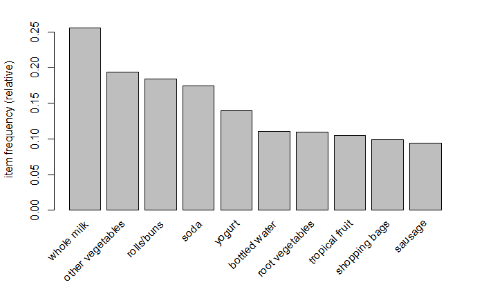

```r
itemFrequencyPlot(Groceries, type = "relative", topN = 10)
```

You could also filter by `support` (only show items with a certain support).

As you saw, the package has quite a broad interface, though we won’t use much of the functionality later.

## b) Frequent Itemset Mining

We can call the mining function right away. Only make sure that you really mine itemsets, and not association rules:

```r
itemsets <- apriori(data = Groceries, parameter = list(supp = 0.05,
    target = "frequent itemsets"))
```

```
Apriori

Parameter specification:
```

|  | confidence | minval | smax | arem | aval | originalSupport | maxtime | support | minlen | maxlen | target | ext |
| --- | --- | --- | --- | --- | --- | --- | --- | --- | --- | --- | --- | --- |
|  | NA | 0.1 | 1 | none | FALSE | TRUE | 5 | 0.05 | 1 | 10 | frequent itemsets | TRUE |

```
Algorithmic control:
```

|  | filter | tree | heap | memopt | load | sort | verbose |
| --- | --- | --- | --- | --- | --- | --- | --- |
|  | 0.1 | TRUE | TRUE | FALSE | TRUE | 2 | TRUE |

```
Absolute minimum support count: 491

set item appearances ...[0 item(s)] done [0.00s].
set transactions ...[169 item(s), 9835 transaction(s)] done [0.02s].
sorting and recoding items ... [28 item(s)] done [0.00s].
creating transaction tree ... done [0.00s].
checking subsets of size 1 2 done [0.00s].
sorting transactions ... done [0.00s].
writing ... [31 set(s)] done [0.00s].
creating S4 object  ... done [0.00s].
```

```r
str(itemsets)
```

```
Formal class 'itemsets' [package "arules"] with 4 slots
  ..@ items   :Formal class 'itemMatrix' [package "arules"] with 3 slots
  .. .. ..@ data       :Formal class 'ngCMatrix' [package "Matrix"] with 5 slots
  .. .. .. .. ..@ i       : int [1:34] 108 98 10 26 152 9 0 107 57 69 ...
  .. .. .. .. ..@ p       : int [1:32] 0 1 2 3 4 5 6 7 8 9 ...
  .. .. .. .. ..@ Dim     : int [1:2] 169 31
  .. .. .. .. ..@ Dimnames:List of 2
  .. .. .. .. .. ..$ : NULL
  .. .. .. .. .. ..$ : NULL
  .. .. .. .. ..@ factors : list()
  .. .. ..@ itemInfo   :'data.frame':   169 obs. of  3 variables:
  .. .. .. ..$ labels: chr [1:169] "frankfurter" "sausage" "liver loaf" "ham" ...
  .. .. .. ..$ level2: Factor w/ 55 levels "baby food","bags",..: 44 44 44 44 44 44 44 42 42 41 ...
  .. .. .. ..$ level1: Factor w/ 10 levels "canned food",..: 6 6 6 6 6 6 6 6 6 6 ...
  .. .. ..@ itemsetInfo:'data.frame':   0 obs. of  0 variables
  ..@ tidLists: NULL
  ..@ quality :'data.frame':    31 obs. of  3 variables:
  .. ..$ support                 : num [1:31] 0.0777 0.0581 0.0525 0.0533 0.0524 ...
  .. ..$ transIdenticalToItemsets: num [1:31] 0.03233 0.00895 0.00458 0.00264 0.00447 ...
  .. ..$ count                   : int [1:31] 764 571 516 524 515 567 580 792 638 576 ...
  ..@ info    :List of 4
  .. ..$ data         : symbol Groceries
  .. ..$ ntransactions: int 9835
  .. ..$ support      : num 0.05
  .. ..$ confidence   : num 1
```

The resulting object again is quite complex. We get the itemsets, quality measures, and information about the initial dataset. Let’s see if the summary is more helpful:

```r
summary(itemsets)
```

```
set of 31 itemsets

most frequent items:
      whole milk other vegetables           yogurt       rolls/buns      frankfurter          (Other)
               4                2                2                2                1               23

element (itemset/transaction) length distribution:sizes
 1  2
28  3

   Min. 1st Qu.  Median    Mean 3rd Qu.    Max.
  1.000   1.000   1.000   1.097   1.000   2.000

summary of quality measures:
    support        transIdenticalToItemsets     count
 Min.   :0.05236   Min.   :0.001932         Min.   : 515.0
 1st Qu.:0.05831   1st Qu.:0.004169         1st Qu.: 573.5
 Median :0.07565   Median :0.005491         Median : 744.0
 Mean   :0.09212   Mean   :0.009036         Mean   : 906.0
 3rd Qu.:0.10173   3rd Qu.:0.010117         3rd Qu.:1000.5
 Max.   :0.25552   Max.   :0.032334         Max.   :2513.0

includes transaction ID lists: FALSE

mining info:
```

|  | data | ntransactions | support | confidence |
| --- | --- | --- | --- | --- |
|  | Groceries | 9835 | 0.05 | 1 |

Already looks better. Let’s have a look at the itemsets:

```r
inspect(itemsets)
```

|  | items | support | transIdenticalToItemsets | count |
| --- | --- | --- | --- | --- |
| [1] | {canned beer} | 0.07768175 | 0.032333503 | 764 |
| [2] | {coffee} | 0.05805796 | 0.008947636 | 571 |
| [3] | {beef} | 0.05246568 | 0.004575496 | 516 |
| [4] | {curd} | 0.05327911 | 0.002643620 | 524 |
| [5] | {napkins} | 0.05236401 | 0.004473818 | 515 |
| [6] | {pork} | 0.05765125 | 0.004270463 | 567 |
| [7] | {frankfurter} | 0.05897306 | 0.003050330 | 580 |
| [8] | {bottled beer} | 0.08052872 | 0.019115404 | 792 |
| [9] | {brown bread} | 0.06487036 | 0.005185562 | 638 |
| [10] | {margarine} | 0.05856634 | 0.002033554 | 576 |

[output cut: 21 more lines]

There are two ways to get maximally frequent itemsets. First, we can post-process our mining result:

```r
summary(itemsets[is.maximal(itemsets)])
```

```
set of 27 itemsets

most frequent items:
 whole milk frankfurter     sausage        pork        beef     (Other)
          3           1           1           1           1          23

element (itemset/transaction) length distribution:sizes
 1  2
24  3

   Min. 1st Qu.  Median    Mean 3rd Qu.    Max.
  1.000   1.000   1.000   1.111   1.000   2.000

summary of quality measures:
    support        transIdenticalToItemsets     count
 Min.   :0.05236   Min.   :0.001932         Min.   : 515.0
 1st Qu.:0.05785   1st Qu.:0.003915         1st Qu.: 569.0
 Median :0.07229   Median :0.005186         Median : 711.0
 Mean   :0.07716   Mean   :0.007724         Mean   : 758.9
 3rd Qu.:0.08587   3rd Qu.:0.008388         3rd Qu.: 844.5
 Max.   :0.17438   Max.   :0.032334         Max.   :1715.0

includes transaction ID lists: FALSE

mining info:
```

|  | data | ntransactions | support | confidence |
| --- | --- | --- | --- | --- |
|  | Groceries | 9835 | 0.05 | 1 |

As you can see, we can index `itemsets` objects like a vector. By the way, you can use `help("rules-class")` and `help("itemsets-class")` to see which methods are available for these objects.

Alternatively, we can also directly mine the maximally frequent itemsets, getting the same result:

```r
itemsets <- apriori(data = Groceries, parameter = list(supp = 0.05,
    target = "maximally frequent itemsets"), control = list(verbose = FALSE))
summary(itemsets)
```

```
set of 27 itemsets

most frequent items:
 whole milk frankfurter     sausage        pork        beef     (Other)
          3           1           1           1           1          23

element (itemset/transaction) length distribution:sizes
 1  2
24  3

   Min. 1st Qu.  Median    Mean 3rd Qu.    Max.
  1.000   1.000   1.000   1.111   1.000   2.000

summary of quality measures:
    support        transIdenticalToItemsets     count
 Min.   :0.05236   Min.   :0.001932         Min.   : 515.0
 1st Qu.:0.05785   1st Qu.:0.003915         1st Qu.: 569.0
 Median :0.07229   Median :0.005186         Median : 711.0
 Mean   :0.07716   Mean   :0.007724         Mean   : 758.9
 3rd Qu.:0.08587   3rd Qu.:0.008388         3rd Qu.: 844.5
 Max.   :0.17438   Max.   :0.032334         Max.   :1715.0

includes transaction ID lists: FALSE

mining info:
```

|  | data | ntransactions | support | confidence |
| --- | --- | --- | --- | --- |
|  | Groceries | 9835 | 0.05 | 1 |

```r
inspect(itemsets)
```

|  | items | support | transIdenticalToItemsets | count |
| --- | --- | --- | --- | --- |
| [1] | {canned beer} | 0.07768175 | 0.032333503 | 764 |
| [2] | {coffee} | 0.05805796 | 0.008947636 | 571 |
| [3] | {beef} | 0.05246568 | 0.004575496 | 516 |
| [4] | {curd} | 0.05327911 | 0.002643620 | 524 |
| [5] | {napkins} | 0.05236401 | 0.004473818 | 515 |
| [6] | {pork} | 0.05765125 | 0.004270463 | 567 |
| [7] | {frankfurter} | 0.05897306 | 0.003050330 | 580 |
| [8] | {bottled beer} | 0.08052872 | 0.019115404 | 792 |
| [9] | {brown bread} | 0.06487036 | 0.005185562 | 638 |
| [10] | {margarine} | 0.05856634 | 0.002033554 | 576 |

[output cut: 17 more lines]

The number of maximally frequent itemsets is lower than the number of frequent itemsets. The algorithm removes all frequent itemsets which are a subset of another frequent itemset. Here, we had some itemsets of size one which were part of frequent itemsets of size two. (Compare the tables with the frequent itemsets!)

## c) Association Rule Mining

We use the same function for association rule mining:

```r
rules <- apriori(data = Groceries, parameter = list(supp = 0.01, conf = 0.4),
                 control = list(verbose = FALSE))
str(rules)
```

```
Formal class 'rules' [package "arules"] with 4 slots
  ..@ lhs    :Formal class 'itemMatrix' [package "arules"] with 3 slots
  .. .. ..@ data       :Formal class 'ngCMatrix' [package "Matrix"] with 5 slots
  .. .. .. .. ..@ i       : int [1:99] 37 28 3 36 68 20 11 11 71 38 ...
  .. .. .. .. ..@ p       : int [1:63] 0 1 2 3 4 5 6 7 8 9 ...
  .. .. .. .. ..@ Dim     : int [1:2] 169 62
  .. .. .. .. ..@ Dimnames:List of 2
  .. .. .. .. .. ..$ : NULL
  .. .. .. .. .. ..$ : NULL
  .. .. .. .. ..@ factors : list()
  .. .. ..@ itemInfo   :'data.frame':   169 obs. of  3 variables:
  .. .. .. ..$ labels: chr [1:169] "frankfurter" "sausage" "liver loaf" "ham" ...
  .. .. .. ..$ level2: Factor w/ 55 levels "baby food","bags",..: 44 44 44 44 44 44 44 42 42 41 ...
  .. .. .. ..$ level1: Factor w/ 10 levels "canned food",..: 6 6 6 6 6 6 6 6 6 6 ...
  .. .. ..@ itemsetInfo:'data.frame':   0 obs. of  0 variables
  ..@ rhs    :Formal class 'itemMatrix' [package "arules"] with 3 slots
  .. .. ..@ data       :Formal class 'ngCMatrix' [package "Matrix"] with 5 slots
  .. .. .. .. ..@ i       : int [1:62] 24 24 24 24 24 22 22 24 24 24 ...
  .. .. .. .. ..@ p       : int [1:63] 0 1 2 3 4 5 6 7 8 9 ...
  .. .. .. .. ..@ Dim     : int [1:2] 169 62
  .. .. .. .. ..@ Dimnames:List of 2
  .. .. .. .. .. ..$ : NULL
  .. .. .. .. .. ..$ : NULL
  .. .. .. .. ..@ factors : list()
  .. .. ..@ itemInfo   :'data.frame':   169 obs. of  3 variables:
  .. .. .. ..$ labels: chr [1:169] "frankfurter" "sausage" "liver loaf" "ham" ...
  .. .. .. ..$ level2: Factor w/ 55 levels "baby food","bags",..: 44 44 44 44 44 44 44 42 42 41 ...
  .. .. .. ..$ level1: Factor w/ 10 levels "canned food",..: 6 6 6 6 6 6 6 6 6 6 ...
  .. .. ..@ itemsetInfo:'data.frame':   0 obs. of  0 variables
  ..@ quality:'data.frame': 62 obs. of  5 variables:
  .. ..$ support   : num [1:62] 0.0101 0.0116 0.0115 0.0108 0.0113 ...
  .. ..$ confidence: num [1:62] 0.411 0.415 0.441 0.44 0.402 ...
  .. ..$ coverage  : num [1:62] 0.0245 0.028 0.026 0.0245 0.0281 ...
  .. ..$ lift      : num [1:62] 1.61 1.62 1.73 1.72 1.57 ...
  .. ..$ count     : int [1:62] 99 114 113 106 111 140 136 145 148 162 ...
  ..@ info   :List of 4
  .. ..$ data         : symbol Groceries
  .. ..$ ntransactions: int 9835
  .. ..$ support      : num 0.01
  .. ..$ confidence   : num 0.4
```

The structure of `rules` objects is somewhat similar to that of `itemsets` objects. Note that we have two objects of class `itemMatrix` now, the left-hand side (`lhs`) and right-hand side (`rhs`). Also, `quality` partly stores different metrics. Again, we get a nice summary:

```r
summary(rules)
```

```
set of 62 rules

rule length distribution (lhs + rhs):sizes
 2  3
25 37

   Min. 1st Qu.  Median    Mean 3rd Qu.    Max.
  2.000   2.000   3.000   2.597   3.000   3.000

summary of quality measures:
    support          confidence        coverage            lift           count
 Min.   :0.01007   Min.   :0.4016   Min.   :0.01729   Min.   :1.572   Min.   : 99.0
 1st Qu.:0.01149   1st Qu.:0.4178   1st Qu.:0.02450   1st Qu.:1.729   1st Qu.:113.0
 Median :0.01388   Median :0.4502   Median :0.03005   Median :1.947   Median :136.5
 Mean   :0.01752   Mean   :0.4643   Mean   :0.03882   Mean   :1.993   Mean   :172.4
 3rd Qu.:0.01790   3rd Qu.:0.4975   3rd Qu.:0.04291   3rd Qu.:2.195   3rd Qu.:176.0
 Max.   :0.05602   Max.   :0.5862   Max.   :0.13950   Max.   :3.030   Max.   :551.0

mining info:
```

|  | data | ntransactions | support | confidence |
| --- | --- | --- | --- | --- |
|  | Groceries | 9835 | 0.01 | 0.4 |

Also, we can access the mined rules:

```r
inspect(rules)
```

|  | lhs |  | rhs | support | confidence | coverage | lift | count |
| --- | --- | --- | --- | --- | --- | --- | --- | --- |
| [1] | {hard cheese} | => | {whole milk} | 0.01006609 | 0.4107884 | 0.02450432 | 1.607682 | 99 |
| [2] | {butter milk} | => | {whole milk} | 0.01159126 | 0.4145455 | 0.02796136 | 1.622385 | 114 |
| [3] | {ham} | => | {whole milk} | 0.01148958 | 0.4414062 | 0.02602949 | 1.727509 | 113 |
| [4] | {sliced cheese} | => | {whole milk} | 0.01077783 | 0.4398340 | 0.02450432 | 1.721356 | 106 |
| [5] | {oil} | => | {whole milk} | 0.01128622 | 0.4021739 | 0.02806304 | 1.573968 | 111 |
| [6] | {onions} | => | {other vegetables} | 0.01423488 | 0.4590164 | 0.03101169 | 2.372268 | 140 |
| [7] | {hamburger meat} | => | {other vegetables} | 0.01382816 | 0.4159021 | 0.03324860 | 2.149447 | 136 |
| [8] | {hamburger meat} | => | {whole milk} | 0.01474326 | 0.4434251 | 0.03324860 | 1.735410 | 145 |
| [9] | {sugar} | => | {whole milk} | 0.01504830 | 0.4444444 | 0.03385867 | 1.739400 | 148 |
| [10] | {cream cheese } | => | {whole milk} | 0.01647178 | 0.4153846 | 0.03965430 | 1.625670 | 162 |

[output cut: 52 more lines]

We filter the mined rules as a post-processing step to answer the two questions from the exercise sheet. The `head()` function is a standard R function which can be applied to `rules` objects: (The function usually returns the first $n$ objects, here it also allows to sort by a criterion)

```r
inspect(head(rules, n = 5, by = "confidence"))
```

|  | lhs |  | rhs | support | confidence | coverage | lift | count |
| --- | --- | --- | --- | --- | --- | --- | --- | --- |
| [1] | {citrus fruit,root vegetables} | => | {other vegetables} | 0.01037112 | 0.5862069 | 0.01769192 | 3.029608 | 102 |
| [2] | {tropical fruit,root vegetables} | => | {other vegetables} | 0.01230300 | 0.5845411 | 0.02104728 | 3.020999 | 121 |
| [3] | {curd,yogurt} | => | {whole milk} | 0.01006609 | 0.5823529 | 0.01728521 | 2.279125 | 99 |
| [4] | {other vegetables,butter} | => | {whole milk} | 0.01148958 | 0.5736041 | 0.02003050 | 2.244885 | 113 |
| [5] | {tropical fruit,root vegetables} | => | {whole milk} | 0.01199797 | 0.5700483 | 0.02104728 | 2.230969 | 118 |

The `subset()` function and the `%in%` operator are also overridden:

```r
inspect(subset(rules, subset = lhs %in% "yogurt" & confidence > 0.5))
```

|  | lhs |  | rhs | support | confidence | coverage | lift | count |
| --- | --- | --- | --- | --- | --- | --- | --- | --- |
| [1] | {curd,yogurt} | => | {whole milk} | 0.01006609 | 0.5823529 | 0.01728521 | 2.279125 | 99 |
| [2] | {yogurt,whipped/sour cream} | => | {whole milk} | 0.01087951 | 0.5245098 | 0.02074225 | 2.052747 | 107 |
| [3] | {tropical fruit,yogurt} | => | {whole milk} | 0.01514997 | 0.5173611 | 0.02928317 | 2.024770 | 149 |
| [4] | {root vegetables,yogurt} | => | {whole milk} | 0.01453991 | 0.5629921 | 0.02582613 | 2.203354 | 143 |
| [5] | {other vegetables,yogurt} | => | {whole milk} | 0.02226741 | 0.5128806 | 0.04341637 | 2.007235 | 219 |

## d) Visualization

The `arulesViz` package overrides the standard plot functionality:

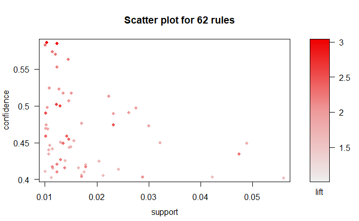

```r
library(arulesViz)
plot(rules)
```

You can create a variety of different plot types; see the help for more details. However, I highly recommend to run `ruleExplorer(rules)` on your PC. You get a web-app with interactive plots and filtering capabilities. Though R is not the programming language of choice for GUIs, the `shiny` package allows building such simple web-apps.

## e) Constraints (1)

We don’t need to use a separate function – `apriori` readily supports simple constraints. You can define the inclusion or exclusion of certain items for both sides of the rules:

```r
rules <- apriori(data = Groceries, parameter = list(supp = 0.01, conf = 0.4),
                 appearance = list(rhs = c("yogurt")), control = list(verbose = FALSE))
inspect(rules)
```

Well, we see nothing. There don’t seem to be any rules matching the criterion. We just need to replace `rhs` with `lhs` to do the same for the left-hand side:

```r
rules <- apriori(data = Groceries, parameter = list(supp = 0.01, conf = 0.4),
                 appearance = list(lhs = c("yogurt")), control = list(verbose = FALSE))
inspect(rules)
```

|  | lhs |  | rhs | support | confidence | coverage | lift | count |
| --- | --- | --- | --- | --- | --- | --- | --- | --- |
| [1] | {yogurt} | => | {whole milk} | 0.0560244 | 0.4016035 | 0.1395018 | 1.571735 | 551 |

Here we have one rule. As you know from the lecture, support of association rules is defined in terms of frequency of the union of LHS itemset and RHS itemset. Thus, from the support perspective, we can swap sides and still get the same result. You see the support above, but we can also compute it manually:

```r
sum(Groceries %ain% c("yogurt", "whole milk")) / length(Groceries)
```

```
[1] 0.0560244
```

The `%ain` operator checks whether transactions contain both the items.

However, confidence divides the support of the rules by the support of the left-hand side. Here, we have a difference between `yogurt` and `whole milk`:

```r
itemFrequency(Groceries)[c("yogurt", "whole milk")]
```

```
    yogurt whole milk
 0.1395018  0.2555160
```

`yogurt` is generally more rare in the dataset than `whole milk`. Thus, the rule with `yogurt` as LHS meets the confidence threshold, while an inverted rule with `whole milk` as LHS has not enough confidence.

## f) Constraints (2)

For post-processing, we use the `%oin%` operator, which checks for set equality:

```r
rules <- apriori(data = Groceries, parameter = list(supp = 0.01, conf = 0.4),
                 control = list(verbose = FALSE))
inspect(subset(rules, subset = rhs %oin% "yogurt"))
```

As we could expect, there are no rules after the post-processing.

```r
inspect(subset(rules, subset = lhs %oin% "yogurt"))
```

|  | lhs |  | rhs | support | confidence | coverage | lift | count |
| --- | --- | --- | --- | --- | --- | --- | --- | --- |
| [1] | {yogurt} | => | {whole milk} | 0.0560244 | 0.4016035 | 0.1395018 | 1.571735 | 551 |

For the other direction, we again get one rule.

Generally, one can obtain the same result by post-processing and by directly considering constraints. Pushing the constraints deeper into mining reduces computational effort, as invalid itemsets / rules are pruned earlier. However, if we wanted to change the constraints, we would have to run the algorithm again. (Unless we want to make the constraints stricter, which can be done by post-processing). Mining more broadly and pruning as post-processing provide more flexibility, e.g., to try alternative constraints. Overall, it depends on your use case if direct use of constraints or post-processing is better.

## g) Multi-Level (1)

As we already noticed when having an initial look at the data, they already contain higher-level categories of the items. Thus, aggregation is quite easy:

```r
groceriesAgg <- aggregate(Groceries, by = "level2")
summary(groceriesAgg)
```

```
transactions as itemMatrix in sparse format with
 9835 rows (elements/itemsets/transactions) and
 55 columns (items) and a density of 0.06858807

most frequent items:
         dairy produce bread and backed goods        non-alc. drinks             vegetables                  fruit                (Other)
                  4357                   3398                   3127                   2685                   2450                  21084

element (itemset/transaction) length distribution:
sizes
   1    2    3    4    5    6    7    8    9   10   11   12   13   14   15   16   17   18   19
2322 1774 1423 1122  953  691  528  370  233  171  105   54   29   22   15   12    5    4    2

   Min. 1st Qu.  Median    Mean 3rd Qu.    Max.
  1.000   2.000   3.000   3.772   5.000  19.000

includes extended item information - examples:
```

|  | labels | level2 | level1 |
| --- | --- | --- | --- |
| 1 | baby food | baby food | canned food |
| 2 | bags | bags | non-food |
| 3 | bakery improver | bakery improver | processed food |

We get a `transactions` object, as we also had before. Note that `labels` and `level2` are the same now. The number of items (= columns) is lower.

We run rule mining as before:

```r
rules <- apriori(data = groceriesAgg, parameter = list(supp = 0.1, conf = 0.4),
                 control = list(verbose = FALSE))
inspect(rules)
```

|  | lhs |  | rhs | support | confidence | coverage | lift | count |
| --- | --- | --- | --- | --- | --- | --- | --- | --- |
| [1] | {} | => | {dairy produce} | 0.4430097 | 0.4430097 | 1.0000000 | 1.000000 | 4357 |
| [2] | {sausage} | => | {bread and backed goods} | 0.1036096 | 0.5478495 | 0.1891205 | 1.585668 | 1019 |
| [3] | {sausage} | => | {dairy produce} | 0.1073716 | 0.5677419 | 0.1891205 | 1.281557 | 1056 |
| [4] | {fruit} | => | {vegetables} | 0.1070666 | 0.4297959 | 0.2491103 | 1.574318 | 1053 |
| [5] | {fruit} | => | {bread and backed goods} | 0.1075750 | 0.4318367 | 0.2491103 | 1.249886 | 1058 |
| [6] | {fruit} | => | {dairy produce} | 0.1563803 | 0.6277551 | 0.2491103 | 1.417024 | 1538 |
| [7] | {non-alc. drinks} | => | {dairy produce} | 0.1519065 | 0.4777742 | 0.3179461 | 1.078474 | 1494 |
| [8] | {vegetables} | => | {bread and backed goods} | 0.1162176 | 0.4256983 | 0.2730046 | 1.232120 | 1143 |
| [9] | {vegetables} | => | {dairy produce} | 0.1704118 | 0.6242086 | 0.2730046 | 1.409018 | 1676 |
| [10] | {bread and backed goods} | => | {dairy produce} | 0.1876970 | 0.5432607 | 0.3455008 | 1.226295 | 1846 |

[output cut: 1 more lines]

Though we basically work with the same transactions, we have much higher supports than before. This is a trivial consequence of merging multiple items to the same category, making the item matrix less sparse. Thus, it makes sense to increase the support threshold when mining on higher levels.

## h) Multi-Level (2)

We extend the dataset by adding the higher-level categories:

```r
groceriesMulti <- addAggregate(Groceries, by = "level2")
summary(groceriesMulti)
```

```
transactions as itemMatrix in sparse format with
 9835 rows (elements/itemsets/transactions) and
 224 columns (items) and a density of 0.03652589

most frequent items:
         dairy produce* bread and backed goods*        non-alc. drinks*             vegetables*              whole milk                 (Other)
                   4357                    3398                    3127                    2685                    2513                   64388

element (itemset/transaction) length distribution:
sizes
   2    3    4    5    6    7    8    9   10   11   12   13   14   15   16   17   18   19   20   21   22   23   24   25   26   27   28   29   30   31
2159  151 1503  234 1094  297  736  320  594  301  376  272  330  218  212  173  163  118  102   89   52   62   49   45   35   31   23   19    8   12
  32   33   34   35   36   37   38   39   40   41   42   47   48   49
  11    6    6    8    5    6    2    3    2    1    2    3    1    1

   Min. 1st Qu.  Median    Mean 3rd Qu.    Max.
  2.000   4.000   6.000   8.182  11.000  49.000

includes extended item information - examples:
```

|  | labels | level2 | level1 | aggregatedBy | aggregateLevels | aggregateID |
| --- | --- | --- | --- | --- | --- | --- |
| 1 | frankfurter | sausage | meat and sausage | NA | 1 | 213 |
| 2 | sausage | sausage | meat and sausage | NA | 1 | 213 |
| 3 | liver loaf | sausage | meat and sausage | NA | 1 | 213 |

```r
inspect(head(groceriesMulti))
```

```
    items
[1] {citrus fruit,
     semi-finished bread,
     margarine,
     ready soups,
     bread and backed goods*,
     fruit*,
     soups/sauces*,
     vinegar/oils*}
[2] {tropical fruit,
     yogurt,
     coffee,
     coffee*,
     dairy produce*,
     fruit*}
[3] {whole milk,
     dairy produce*}
[4] {pip fruit,
     yogurt,
     cream cheese ,
     meat spreads,
     cheese*,
     dairy produce*,
     fruit*,
     meat spreads*}
[5] {other vegetables,
     whole milk,
     condensed milk,
     long life bakery product,
     dairy produce*,
     long-life bakery products*,
     shelf-stable dairy*,
     vegetables*}
[6] {whole milk,
     butter,
     yogurt,
     rice,
     abrasive cleaner,
     cleaner*,
     dairy produce*,
     staple foods*}
```

As you can see, the new itemsets are the union of the old itemsets and the old categories now. A star denotes the latter.

We can apply the mining algorithm as usual:

```r
rules <- apriori(data = groceriesMulti, parameter = list(supp = 0.1, conf = 0.4),
                 control = list(verbose = FALSE))
inspect(rules)
```

|  | lhs |  | rhs | support | confidence | coverage | lift | count |
| --- | --- | --- | --- | --- | --- | --- | --- | --- |
| [1] | {} | => | {dairy produce*} | 0.4430097 | 0.4430097 | 1.0000000 | 1.000000 | 4357 |
| [2] | {bottled water} | => | {non-alc. drinks*} | 0.1105236 | 1.0000000 | 0.1105236 | 3.145187 | 1087 |
| [3] | {tropical fruit} | => | {fruit*} | 0.1049314 | 1.0000000 | 0.1049314 | 4.014286 | 1032 |
| [4] | {fruit*} | => | {tropical fruit} | 0.1049314 | 0.4212245 | 0.2491103 | 4.014286 | 1032 |
| [5] | {root vegetables} | => | {vegetables*} | 0.1089985 | 1.0000000 | 0.1089985 | 3.662942 | 1072 |
| [6] | {yogurt} | => | {dairy produce*} | 0.1395018 | 1.0000000 | 0.1395018 | 2.257287 | 1372 |
| [7] | {soda} | => | {non-alc. drinks*} | 0.1743772 | 1.0000000 | 0.1743772 | 3.145187 | 1715 |
| [8] | {non-alc. drinks*} | => | {soda} | 0.1743772 | 0.5484490 | 0.3179461 | 3.145187 | 1715 |
| [9] | {rolls/buns} | => | {bread and backed goods*} | 0.1839349 | 1.0000000 | 0.1839349 | 2.894350 | 1809 |
| [10] | {bread and backed goods*} | => | {rolls/buns} | 0.1839349 | 0.5323720 | 0.3455008 | 2.894350 | 1809 |

[output cut: 26 more lines]

In the rules, we see a lot higher-level information, as it has an advantage in meeting the support threshold. Also, we notice a lot of rules involving items and their categories, e.g. `tropical fruit` and `fruit`. What could also happen, but what we don’t have here (because of the support threshold) is that a similar rule appears as a low-level version and a high-level version. `filterAggregate` removes the rules between items and categories:

```r
inspect(filterAggregate(rules))
```

|  | lhs |  | rhs | support | confidence | coverage | lift | count |
| --- | --- | --- | --- | --- | --- | --- | --- | --- |
| [1] | {} | => | {dairy produce*} | 0.4430097 | 0.4430097 | 1.0000000 | 1.000000 | 4357 |
| [2] | {sausage*} | => | {bread and backed goods*} | 0.1036096 | 0.5478495 | 0.1891205 | 1.585668 | 1019 |
| [3] | {sausage*} | => | {dairy produce*} | 0.1073716 | 0.5677419 | 0.1891205 | 1.281557 | 1056 |
| [4] | {other vegetables} | => | {dairy produce*} | 0.1220132 | 0.6305833 | 0.1934926 | 1.423408 | 1200 |
| [5] | {whole milk} | => | {vegetables*} | 0.1062532 | 0.4158376 | 0.2555160 | 1.523189 | 1045 |
| [6] | {whole milk} | => | {bread and backed goods*} | 0.1141840 | 0.4468762 | 0.2555160 | 1.293416 | 1123 |
| [7] | {fruit*} | => | {vegetables*} | 0.1070666 | 0.4297959 | 0.2491103 | 1.574318 | 1053 |
| [8] | {fruit*} | => | {bread and backed goods*} | 0.1075750 | 0.4318367 | 0.2491103 | 1.249886 | 1058 |
| [9] | {fruit*} | => | {dairy produce*} | 0.1563803 | 0.6277551 | 0.2491103 | 1.417024 | 1538 |
| [10] | {non-alc. drinks*} | => | {dairy produce*} | 0.1519065 | 0.4777742 | 0.3179461 | 1.078474 | 1494 |

[output cut: 4 more lines]

## i) Classification (1)

We could discretize the dataset manually. However, `arulesCBA` also supports multiple discretization options. Here, we use an MDL-based approach.

```r
library(arulesCBA)
irisDiscretized <- discretizeDF.supervised(Species ~ ., iris, method = "mdlp")
head(irisDiscretized)
```

|  | Sepal.Length | Sepal.Width | Petal.Length | Petal.Width | Species |
| --- | --- | --- | --- | --- | --- |
| 1 | [-Inf,5.55) | [3.35, Inf] | [-Inf,2.45) | [-Inf,0.8) | setosa |
| 2 | [-Inf,5.55) | [2.95,3.35) | [-Inf,2.45) | [-Inf,0.8) | setosa |
| 3 | [-Inf,5.55) | [2.95,3.35) | [-Inf,2.45) | [-Inf,0.8) | setosa |
| 4 | [-Inf,5.55) | [2.95,3.35) | [-Inf,2.45) | [-Inf,0.8) | setosa |
| 5 | [-Inf,5.55) | [3.35, Inf] | [-Inf,2.45) | [-Inf,0.8) | setosa |
| 6 | [-Inf,5.55) | [3.35, Inf] | [-Inf,2.45) | [-Inf,0.8) | setosa |

`arules` allows to cast data frames into transactions:

```r
irisTransactions <- as(irisDiscretized, "transactions")
summary(irisTransactions)
```

```
transactions as itemMatrix in sparse format with
 150 rows (elements/itemsets/transactions) and
 15 columns (items) and a density of 0.3333333

most frequent items:
Sepal.Length=[-Inf,5.55)  Sepal.Width=[-Inf,2.95)  Sepal.Width=[2.95,3.35) Sepal.Length=[6.15, Inf] Petal.Length=[4.75, Inf]                  (Other)
                      59                       57                       56                       55                       55                      468

element (itemset/transaction) length distribution:
sizes
  5
150

   Min. 1st Qu.  Median    Mean 3rd Qu.    Max.
      5       5       5       5       5       5

includes extended item information - examples:
```

|  | labels | variables | levels |
| --- | --- | --- | --- |
| 1 | Sepal.Length=[-Inf,5.55) | Sepal.Length | [-Inf,5.55) |
| 2 | Sepal.Length=[5.55,6.15) | Sepal.Length | [5.55,6.15) |
| 3 | Sepal.Length=[6.15, Inf] | Sepal.Length | [6.15, Inf] |

```
includes extended transaction information - examples:
```

|  | transactionID |
| --- | --- |
| 1 | 1 |
| 2 | 2 |
| 3 | 3 |

```r
inspect(head(irisTransactions))
```

```
    items                      transactionID
[1] {Sepal.Length=[-Inf,5.55),
     Sepal.Width=[3.35, Inf],
     Petal.Length=[-Inf,2.45),
     Petal.Width=[-Inf,0.8),
     Species=setosa}                       1
[2] {Sepal.Length=[-Inf,5.55),
     Sepal.Width=[2.95,3.35),
     Petal.Length=[-Inf,2.45),
     Petal.Width=[-Inf,0.8),
     Species=setosa}                       2
[3] {Sepal.Length=[-Inf,5.55),
     Sepal.Width=[2.95,3.35),
     Petal.Length=[-Inf,2.45),
     Petal.Width=[-Inf,0.8),
     Species=setosa}                       3
[4] {Sepal.Length=[-Inf,5.55),
     Sepal.Width=[2.95,3.35),
     Petal.Length=[-Inf,2.45),
     Petal.Width=[-Inf,0.8),
     Species=setosa}                       4
[5] {Sepal.Length=[-Inf,5.55),
     Sepal.Width=[3.35, Inf],
     Petal.Length=[-Inf,2.45),
     Petal.Width=[-Inf,0.8),
     Species=setosa}                       5
[6] {Sepal.Length=[-Inf,5.55),
     Sepal.Width=[3.35, Inf],
     Petal.Length=[-Inf,2.45),
     Petal.Width=[-Inf,0.8),
     Species=setosa}                       6
```

Each row becomes a transaction, each categorical value becomes an item. All transactions have the same size We can mine classification rules manually:

```r
rules <- apriori(irisTransactions, parameter = list(support = 0.2, confidence = 0.9),
                 control = list(verbose = FALSE))
rules <- subset(rules, subset = rhs %pin% "Species")
inspect(rules)
```

|  | lhs |  | rhs | support | confidence | coverage | lift | count |
| --- | --- | --- | --- | --- | --- | --- | --- | --- |
| [1] | {Petal.Length=[2.45,4.75)} | => | {Species=versicolor} | 0.2933333 | 0.9777778 | 0.3000000 | 2.933333 | 44 |
| [2] | {Petal.Width=[1.75, Inf]} | => | {Species=virginica} | 0.3000000 | 0.9782609 | 0.3066667 | 2.934783 | 45 |
| [3] | {Petal.Length=[-Inf,2.45)} | => | {Species=setosa} | 0.3333333 | 1.0000000 | 0.3333333 | 3.000000 | 50 |
| [4] | {Petal.Width=[-Inf,0.8)} | => | {Species=setosa} | 0.3333333 | 1.0000000 | 0.3333333 | 3.000000 | 50 |
| [5] | {Petal.Width=[0.8,1.75)} | => | {Species=versicolor} | 0.3266667 | 0.9074074 | 0.3600000 | 2.722222 | 49 |
| [6] | {Sepal.Width=[3.35, Inf],Petal.Length=[-Inf,2.45)} | => | {Species=setosa} | 0.2066667 | 1.0000000 | 0.2066667 | 3.000000 | 31 |
| [7] | {Sepal.Width=[3.35, Inf],Petal.Width=[-Inf,0.8)} | => | {Species=setosa} | 0.2066667 | 1.0000000 | 0.2066667 | 3.000000 | 31 |
| [8] | {Petal.Length=[2.45,4.75),Petal.Width=[0.8,1.75)} | => | {Species=versicolor} | 0.2933333 | 0.9777778 | 0.3000000 | 2.933333 | 44 |
| [9] | {Sepal.Width=[-Inf,2.95),Petal.Length=[2.45,4.75)} | => | {Species=versicolor} | 0.2066667 | 0.9687500 | 0.2133333 | 2.906250 | 31 |
| [10] | {Sepal.Length=[6.15, Inf],Petal.Width=[1.75, Inf]} | => | {Species=virginica} | 0.2466667 | 1.0000000 | 0.2466667 | 3.000000 | 37 |

[output cut: 9 more lines]

We use a post-processing approach, because that way we can partially match the class-related items with `%pin%`. (For constrain-based mining, we needed to specify all item names related to the class.) The resulting rules have high confidence, which we can take as a good sign for classification. In fact, the rule-mining approach even has the advantage that we can control this quality criterion during mining. Furthermore, the resulting rules are interpretable. However, one can also see it as a downside that we have to define these quality criteria, as they clearly have a trade-off. It is not trivial to find a point which is optimal regarding a classification performance metric. Confidence can be seen as a kind of precision measure, but it is rule-specific. Rules might only describe a small part of the dataset. We can still control this with the support threshold. What we cannot control is how the rules interact, e.g., if they are redundant. Some data objects might be covered by multiple rules or no rule. We will see an approach to counter this in the next sub-task.

However, before we continue, just have a look how `arulesCBA` can find the same rules, with a more classification-like interface:

```r
rules <- mineCARs(Species ~ ., transactions = irisTransactions, parameter = list(
  support = 0.2, confidence = 0.9), control = list(verbose = FALSE))
inspect(rules)
```

|  | lhs |  | rhs | support | confidence | coverage | lift | count |
| --- | --- | --- | --- | --- | --- | --- | --- | --- |
| [1] | {Petal.Length=[2.45,4.75)} | => | {Species=versicolor} | 0.2933333 | 0.9777778 | 0.3000000 | 2.933333 | 44 |
| [2] | {Petal.Width=[1.75, Inf]} | => | {Species=virginica} | 0.3000000 | 0.9782609 | 0.3066667 | 2.934783 | 45 |
| [3] | {Petal.Length=[-Inf,2.45)} | => | {Species=setosa} | 0.3333333 | 1.0000000 | 0.3333333 | 3.000000 | 50 |
| [4] | {Petal.Width=[-Inf,0.8)} | => | {Species=setosa} | 0.3333333 | 1.0000000 | 0.3333333 | 3.000000 | 50 |
| [5] | {Petal.Width=[0.8,1.75)} | => | {Species=versicolor} | 0.3266667 | 0.9074074 | 0.3600000 | 2.722222 | 49 |
| [6] | {Sepal.Width=[3.35, Inf],Petal.Length=[-Inf,2.45)} | => | {Species=setosa} | 0.2066667 | 1.0000000 | 0.2066667 | 3.000000 | 31 |
| [7] | {Sepal.Width=[3.35, Inf],Petal.Width=[-Inf,0.8)} | => | {Species=setosa} | 0.2066667 | 1.0000000 | 0.2066667 | 3.000000 | 31 |
| [8] | {Petal.Length=[2.45,4.75),Petal.Width=[0.8,1.75)} | => | {Species=versicolor} | 0.2933333 | 0.9777778 | 0.3000000 | 2.933333 | 44 |
| [9] | {Sepal.Width=[-Inf,2.95),Petal.Length=[2.45,4.75)} | => | {Species=versicolor} | 0.2066667 | 0.9687500 | 0.2133333 | 2.906250 | 31 |
| [10] | {Sepal.Length=[6.15, Inf],Petal.Width=[1.75, Inf]} | => | {Species=virginica} | 0.2466667 | 1.0000000 | 0.2466667 | 3.000000 | 37 |

[output cut: 9 more lines]

## j) Classification (2)

Another disadvantage of the previous implementation is that does not produce a model with prediction functionality. This is where `CBA()` comes into play:

```r
cbaModel <- CBA(Species ~ ., data = irisTransactions, support = 0.2, confidence = 0.9)
str(cbaModel)
```

```
List of 7
 $ formula       :Class 'formula'  language Species ~ .
  .. ..- attr(*, ".Environment")=<environment: R_GlobalEnv>
 $ discretization: NULL
 $ parameter     :List of 3
  ..$ support   : num 0.2
  ..$ confidence: num 0.9
  ..$           : NULL
 $ rules         :Formal class 'rules' [package "arules"] with 4 slots
  .. ..@ lhs    :Formal class 'itemMatrix' [package "arules"] with 3 slots
  .. .. .. ..@ data       :Formal class 'ngCMatrix' [package "Matrix"] with 5 slots
  .. .. .. .. .. ..@ i       : int [1:4] 6 2 11 11
  .. .. .. .. .. ..@ p       : int [1:5] 0 1 3 4 4
  .. .. .. .. .. ..@ Dim     : int [1:2] 15 4
  .. .. .. .. .. ..@ Dimnames:List of 2
  .. .. .. .. .. .. ..$ : NULL
  .. .. .. .. .. .. ..$ : NULL
  .. .. .. .. .. ..@ factors : list()
  .. .. .. ..@ itemInfo   :'data.frame':    15 obs. of  3 variables:
  .. .. .. .. ..$ labels   : chr [1:15] "Sepal.Length=[-Inf,5.55)" "Sepal.Length=[5.55,6.15)" "Sepal.Length=[6.15, Inf]" "Sepal.Width=[-Inf,2.95)" ...
  .. .. .. .. ..$ variables: Factor w/ 5 levels "Petal.Length",..: 3 3 3 4 4 4 1 1 1 2 ...
  .. .. .. .. ..$ levels   : Factor w/ 15 levels "[-Inf,0.8)","[-Inf,2.45)",..: 4 11 12 3 8 9 2 7 10 1 ...
  .. .. .. ..@ itemsetInfo:'data.frame':    0 obs. of  0 variables
  .. ..@ rhs    :Formal class 'itemMatrix' [package "arules"] with 3 slots
  .. .. .. ..@ data       :Formal class 'ngCMatrix' [package "Matrix"] with 5 slots
  .. .. .. .. .. ..@ i       : int [1:4] 12 14 14 13
  .. .. .. .. .. ..@ p       : int [1:5] 0 1 2 3 4
  .. .. .. .. .. ..@ Dim     : int [1:2] 15 4
  .. .. .. .. .. ..@ Dimnames:List of 2
  .. .. .. .. .. .. ..$ : NULL
  .. .. .. .. .. .. ..$ : NULL
  .. .. .. .. .. ..@ factors : list()
  .. .. .. ..@ itemInfo   :'data.frame':    15 obs. of  3 variables:
  .. .. .. .. ..$ labels   : chr [1:15] "Sepal.Length=[-Inf,5.55)" "Sepal.Length=[5.55,6.15)" "Sepal.Length=[6.15, Inf]" "Sepal.Width=[-Inf,2.95)" ...
  .. .. .. .. ..$ variables: Factor w/ 5 levels "Petal.Length",..: 3 3 3 4 4 4 1 1 1 2 ...
  .. .. .. .. ..$ levels   : Factor w/ 15 levels "[-Inf,0.8)","[-Inf,2.45)",..: 4 11 12 3 8 9 2 7 10 1 ...
  .. .. .. ..@ itemsetInfo:'data.frame':    0 obs. of  0 variables
  .. ..@ quality:'data.frame':  4 obs. of  8 variables:
  .. .. ..$ support            : num [1:4] 0.333 0.247 0.3 0.333
  .. .. ..$ confidence         : num [1:4] 1 1 0.978 0.333
  .. .. ..$ coverage           : num [1:4] 0.333 0.247 0.307 NA
  .. .. ..$ lift               : num [1:4] 3 3 2.93 1
  .. .. ..$ count              : int [1:4] 50 37 45 150
  .. .. ..$ size               : num [1:4] 2 3 2 1
  .. .. ..$ coveredTransactions: num [1:4] 50 37 9 54
  .. .. ..$ totalErrors        : num [1:4] 50 13 6 6
  .. ..@ info   :List of 2
  .. .. ..$ defaultClass: chr "Species=versicolor"
  .. .. ..$ pruning     : chr "CBA_M1"
 $ default       : logi NA
 $ method        : chr "first"
 $ description   : chr "CBA algorithm (Liu et al., 1998)"
 - attr(*, "class")= chr "CBA"
```

We get a prediction model build around a `rules` object. Also, the number of rules is reduced compared to before:

```r
inspect(cbaModel$rules)
```

|  | lhs |  | rhs | support | confidence | coverage | lift | count | size | coveredTransactions | totalErrors |
| --- | --- | --- | --- | --- | --- | --- | --- | --- | --- | --- | --- |
| [1] | {Petal.Length=[-Inf,2.45)} | => | {Species=setosa} | 0.3333333 | 1.0000000 | 0.3333333 | 3.000000 | 50 | 2 | 50 | 50 |
| [2] | {Sepal.Length=[6.15, Inf],Petal.Width=[1.75, Inf]} | => | {Species=virginica} | 0.2466667 | 1.0000000 | 0.2466667 | 3.000000 | 37 | 3 | 37 | 13 |
| [3] | {Petal.Width=[1.75, Inf]} | => | {Species=virginica} | 0.3000000 | 0.9782609 | 0.3066667 | 2.934783 | 45 | 2 | 9 | 6 |
| [4] | {} | => | {Species=versicolor} | 0.3333333 | 0.3333333 | NA | 1.000000 | 150 | 1 | 54 | 6 |

This is because the CBA algorithm uses additional pruning to get a smaller set of rules with good prediction performance. The last rule is a default for data objects not matched by any other rule. Let’s have a look at the train set performance:

```r
prediction <- predict(cbaModel, irisTransactions)
cat("Accuracy:", sum(prediction == iris$Species) / length(prediction))
```

```
Accuracy: 0.96
```

Looks good.

As you saw, association rules might provide a good baseline for classification tasks. Even apart from the prediction model, just learning and inspecting the rules might provide interesting insights. By the way, alternative packages for classification with association rules are `arc` and `rCBA`.